# The Instrument

#### by Dara Storer

The data you will be working with here was collected by the Hydrogen Epoch of Reionization Array (HERA), a radio interferometer located in South Africa. For general information about HERA, you can visit their website at https://reionization.org/. More detailed information about the telescope design can be found in this paper: https://arxiv.org/pdf/1606.07473.pdf. (You don't need to read this whole paper, only use it if you are hunting for particular information you think will be useful). Some terms that might be useful:

#### Interferometer

Interferometers (as opposed to “single dish” radio telescopes) consist of a large number of antennas which are connected to a central (super-)computer called a correlator. The job of the correlator is to take the signal from every antenna and correlate it with the signal from every other antenna. So, for example, an array with 128 independent antennas will produce 8,128 independent correlations.

A principal advantage of interferometers is that they can make high resolution images over a large area of the sky. For a single dish telescope, both the resolution and the field of view (i.e. how much of the sky the telescope is sensitive to at any given time) are the same — i.e. a single dish telescope can be thought of as a single pixel camera. To make images, a single dish scans its one pixel across the sky. For an interferometer, however, the resolution is effectively set by the largest antenna separation, while the field of view is set by the size of any single antenna in the array. So for example, an interferometer 300 meters across, with individual antenna elements 10 meters in size, has the same resolution as a 300 meter single dish telescope — but a field of view 900 times bigger!

For HERA, the dishes are arranged in hexagonal arrays - see https://reionization.org/science/technical-design/ for images/visualization of this.

#### Baseline

A baseline refers to a pair of dishes. The length and orientation of a baseline is given by the separation vector between the two dishes.

#### Visibility

A visibility is the actual data product we will look at. Visibilities essentially a measure of the response of a particular baseline to incoming radiation from the sky. So, our final data product will contain a measurement of the visibility for each baseline in the array. Note: the visibilities are complex numbers - you may want to think about the best way to deal with that.

There are two "types" of visibilities: cross-correlations and auto-correlations. Cross-correlations are visibilities corresponding to a baseline between two different antennas, which is the primary data product. Auto-correlations are visibilities corresponding to the correlation between an antenna and itself. Auto-correlations are not typically used for "science", but they can be useful in diagnosing problems with individual antennas, because they only contain information from one antenna.

### Some more useful info

If the above definitions are confusing, or you'd like to find more information on interferometry, there is a textbook on the subject available here: http://www.phys.unm.edu/~gbtaylor/astr423/s98book.pdf. This book goes in much more depth than you need, and is a little outdated in some areas. However, the beginning of Lecture 2 might be a helpful introduction, and you can use the index to search for a particular term that might confuse you.

# Reading the Data

The easiest way to read these data files will be to use the software package pyuvdata. Start by getting [pyuvdata](https://pyuvdata.readthedocs.io/en/latest/) working on your computer.

### Python on your machine, install the pyuvdata package

`conda install -c conda-forge pyuvdata`

### Cloud python

Unfortunately the UW IT is scrambling and has not been able to update the instance with a permananent installation of pyuvdata. You can install it yourself using the above command via the terminal (takes about a minute), but you will need to reinstall every time your server restarts (has been idle for a while). A pain in the butt, but it works reliably.

You will also need to use `wget` to download the data using the `wget -O {filename_to_use} {url_link_to_data}` commands in the terminal.

If you have trouble with this installation, more instructions can be found at https://github.com/RadioAstronomySoftwareGroup/pyuvdata. Below is some sample code for reading files into pyuvdata and accessing the data. If you are looking for additional functionality, the full documentation for pyuvdata can be found at https://pyuvdata.readthedocs.io/en/latest/tutorial.html. This includes lots of functionality that doesn't apply to you, so don't spend too much time digging into this. However, there are some examples in the tutorial section that you might find helpful.

```python
from pyuvdata import UVData
import numpy as np
from matplotlib import pyplot as plt
```

```python
uv = UVData()
uv.read('{path_to_data_file}/zen.2459122.34011.mini.sum.uvh5')
data = uv.data_array
print('This data array has shape:')
print('(# baselines*times, # spectral windows, # frequencies, # polarizations)')
print(np.shape(data))
```

```
This data array has shape:
(# baselines*times, # spectral windows, # frequencies, # polarizations)
(13320, 1, 1536, 1)
```

This data array is your desired data product - it contains the visibilities collected by the array. NOTE: Don't worry about what '# spectral windows' means. This axis should only have length 1 for your data. We have also only included the XX polarization of the data (which corresponds physically to the North-North polarization).

The 'baselines*times' axis can be confusing to navigate. There is more information on it in the pyuvdata docs linked above, but you can also avoid dealing with it by reading the data in smaller chunks. Simply pick your two favorite antennas and a polarization, and then you can extract the data as such:

```python
# Look at the antennas that are contained in the array:
print(sorted(uv.antenna_numbers))
# Pick 2 sample antennas, and get data from that baseline. Note that to get the 'auto-correlations', you can do the
# same thing, but set antenna1 and antenna2 to be the same value.
antenna1 = 140
antenna2 = 23
data = uv.get_data(antenna1,antenna2)
```

```
[0, 1, 2, 11, 12, 13, 14, 23, 24, 25, 26, 36, 37, 38, 39, 44, 45, 46, 50, 51, 52, 53, 58, 59, 65, 66, 67, 68, 73, 75, 81, 82, 83, 84, 85, 86, 87, 88, 89, 90, 91, 92, 93, 94, 98, 99, 100, 101, 102, 103, 104, 105, 107, 108, 109, 110, 111, 112, 116, 117, 118, 119, 120, 121, 122, 123, 124, 127, 128, 129…
```

There are many ways you can inspect this data, and many types of plots you could utilize. As an example, below is some sample code that will create a 'waterfall plot' for a particular baseline. (A waterfall plot is one that shows evolution in time)

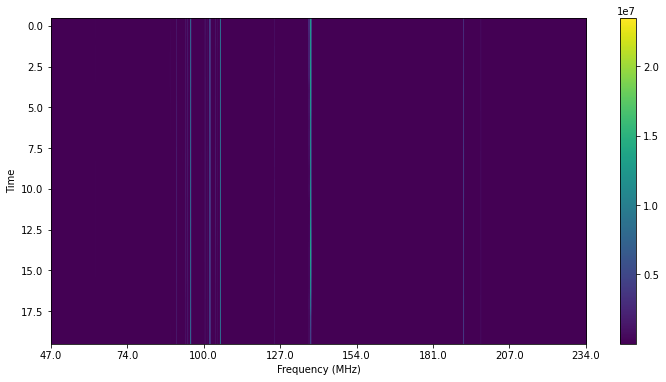

```python
fig, axs = plt.subplots(1,1,figsize=(12,6))
im = plt.imshow(np.abs(data),aspect='auto')
cbar = fig.colorbar(im)
freqs = uv.freq_array[0]*1e-6 #gets frequencies associated with each channel, in MHz
axs.set_ylabel('Time')
axs.set_xlabel('Frequency (MHz)')
xticks = [int(i) for i in np.linspace(0,len(freqs)-1,8)]
_ = axs.set_xticks(xticks)
xticklabels = np.around(freqs[xticks],0)
_ = axs.set_xticklabels(xticklabels)
```

Note: The values on the y-axis of this plot are simply indices of the array, not physical units

## Exploring the Data

Now you have the tools to read and make a basic plot of the data, but the above plot is hard to interpret, and doesn't seem to be telling us much. So, how can we look closer? Here are a few questions you might ask yourselves:

```
- How can I set the color scale so I can see the most detail?
- What can I do to the data to bring out smaller features? (You may consider exploring logarithms).
- What data product will help me identify antennas that may be broken, or have individual problems?
- Do I see structures as a function of frequency or time that seem concerning or not sky-like? Could I take slices of the current data product to see this more clearly?
```

### Working in Matlab

It will be easiest to process this data directly in python, but it should be possible do it in Matlab instead if you wish. You can read the data directly using hdf5 (it is large, so you may want to only load in pieces at a time, but this is one of the neat features of hdf5). That said, the internal data structure is complicated, so you will want to read the documentation at pyuvdata and even the low level read documentation (in python) at read_uvh5 source